# Informe

# Análisis de las características de las pacientes con cáncer de mama en Estados Unidos entre los años 2017 y 2022

## I. Introducción

### 1. Relevancia

El estudio del cáncer de mama es de suma importancia debido a su alta incidencia en las mujeres. Según la Organización Mundial de la Salud, cada año se pronostican más de dos millones de casos nuevos en todo el mundo. Esta enfermedad es una de las principales causas de muerte por cáncer en las mujeres. Nuestra investigación busca describir el comportamiento de distintos factores que determinar el estado final de una paciente.

### 2. Objetivos

#### 2.1 Objetivo general

Analizar las características de las pacientes con cáncer de mama en Estados Unidos entre los años 2017 y 2022 con el fin de describir el comportamiento de las variables.

#### 2.2 Objetivos específicos

- Explorar las distribuciones de las proteínas de las pacientes
- Establecer si existe alguna relación entre el tipo de cirugía realizada con las etapas del tumor
- Hallar la proporción de pacientes vivas y fallecidas por etapa del tumor

### 3. Conceptos relevantes

- Nivel de expresión de una proteína: Se definen cuatro proteínas. Los valores asignados a cada una de estas variables se refieren al nivel de expresión del gen de cada una de ellas, por lo que pueden tomar valores positivos y negativos. El término nivel de expresión negativo en el contexto de una proteína indica que no se está produciendo o se encuentra en cantidades muy bajas en una muestra o célula específica. Cuando es positivo es el caso contrario.
- El estado positivo de HER2 significa que las células cancerígenas de la paciente tienen niveles más altos de HRE2 de lo normal, lo que implica que el cáncer tiende a crecer y propagarse más rápido que otros tipos de cáncer de seno.
- Con histología nos referimos al tipo de cáncer de mama acorde al tipo específico de células afectadas en cada caso.
- Se encuentran 4 tipos: `Lumpectomía`, `Mastectomía Simple` y `Mastectomía Radical Modificada` y `Otra`. En el primer tipo de cirugía, se extirpa el ćancer u otro tejido mamario anormal. En “Mastectomía Simple”, se extirpa todo el seno (pezón, areola y piel). Para el tercer tipo, se extirpa también todo el seno y se realiza una extirpación de los ganglios linfáticos auxiliares. El cuarto se refiere a alguna operación diferente de las tres mencionadas anteriormente.
- Etapas del tumor: Existen tres etapas del tumor en la base de datos. La etapa 1 (`I`) indica que el cáncer ocupa un área relativamente pequeña y no se ha propagado a los ganglios linfáticos o que hay una propagación ligera. La etapa 2 (`II`) sugiere que ocupa un área mayor y que se ha propagado a algunos ganglios adyacentes. En la etapa 3 (`III`) se tiene un tumor grande o que invade los tejidos cercanos o que se ha propagado a muchos ganglios linfáticos adyacentes.
- El estado del paciente indica si es que en el periodo en que se tomaron los datos, el paciente falleció o no durante el periodo de tiempo de 2017 a 2022.
- Las proteínas quinasas que interactúan con el receptor (RIP) son un grupo de proteínas quinasas de treonina/serina con un dominio quinasa relativamente conservado pero regiones no quinasas distintas. Los miembros de la familia de quinasas de proteínas que interactúan con el receptor (RIP) han surgido como sensores esenciales de estrés intracelular y extracelular. Se ha demostrado que desempeñan un papel importante no solo en la inflamación y otras respuestas inmunitarias, sino también en los procesos que inducen la muerte.

### Proceso de recolección de datos

Se obtuvieron los datos a partir de una fuente secundaria. Es un dataset que cuenta con 334 observaciones. El enlace es el siguiente: https://www.kaggle.com/datasets/kreeshrajani/breast-cancer-survival-dataset

### Población, muestra y muestreo

Los datos provienen de [Bio GPS](http://biogps.org/dataset/tag/brca1/) Esta página recopila datos de genes regularmente de fuentes de datos comunes (principalmente [NCBI](https://www.ncbi.nlm.nih.gov/) y [Ensembl](https://www.ensembl.org/index.html)).

## II. Análisis descriptivo

### 1. Variables de estudio

Antes de continuar, se definirán unas funciones que resultarán útiles para describir los datos

```r
CV <- function(x, na.rm=FALSE) {
  return (sd(x, na.rm=na.rm) / mean(x, na.rm=na.rm))
}
```

```r
Moda <- function(x) {
  return (table(x)[which.max(table(x))])
}
```

```r
R <- function(x) {
  return (round(x, digits=2))
}
```

```r
describir <- function(x) {
  return (c("Min"=min(x, na.rm=TRUE),"Max"=max(x, na.rm=TRUE),"Media"=mean(x, na.rm=TRUE), "Mediana"=median(x, na.rm=TRUE), "Desviación Estándar"=sd(x, na.rm=TRUE), "Coeficiente de Variación"=CV(x, na.rm=TRUE), "Rango Intercuartil"=IQR(x, na.rm=TRUE)) %>% R)
}
```

#### Análisis de `Etapa_del_Tumor`

```
## # A tibble: 3 x 3
##   Etapa_del_Tumor     n FreqRel
##   <chr>           <int>   <dbl>
## 1 I                  61   0.192
## 2 II                179   0.565
## 3 III                77   0.243
```

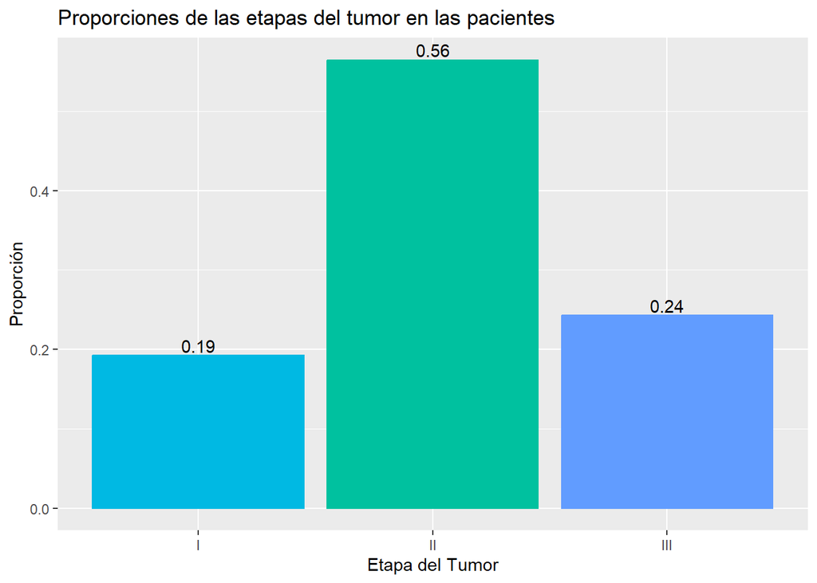

El gráfico sugiere que más de la mitad de las pacientes se encuentra en etapa II de cáncer de mama.

#### Análisis de `Histología`

Realizamos una tabla para observar las frecuencias relativa y absoluta de la variable `Histología`

```
## # A tibble: 3 x 3
##   Histología                        n FreqRel
##   <chr>                         <int>   <dbl>
## 1 Carcinoma Ductal Infiltrante    224  0.707
## 2 Carcinoma Lobular Infiltrante    81  0.256
## 3 Carcinoma Mucinoso               12  0.0379
```

A partir de la tabla, graficamos para observar mejor las proporciones

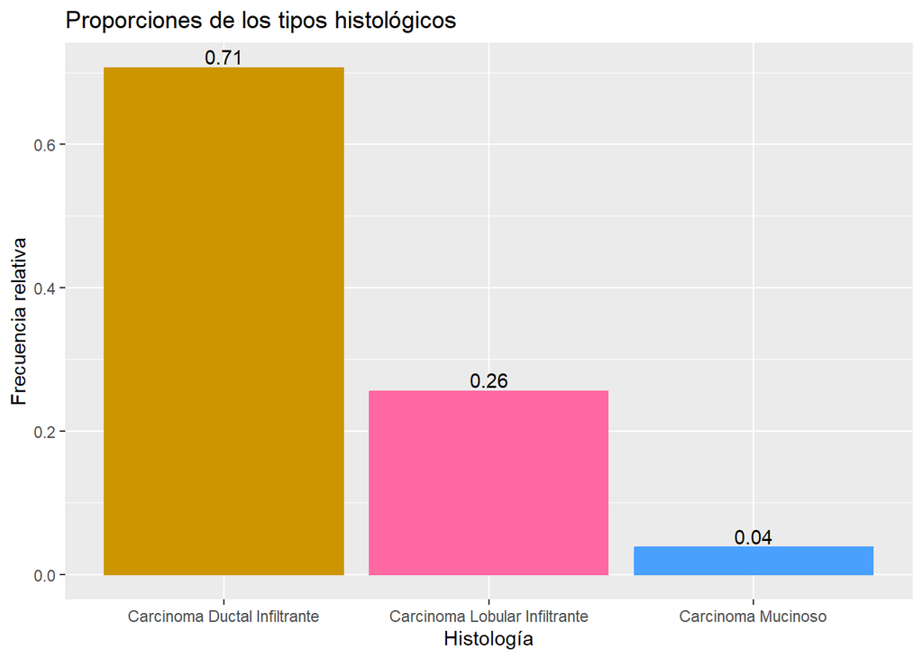

La mayoría de pacientes tiene cáncer de mama de tipo histológico Carcinoma Ductal Infiltrante.

#### Análisis de `Tipo_de_Cirugía`

```
## # A tibble: 4 x 3
##   Tipo_de_Cirugía                    n FreqRel
##   <chr>                          <int>   <dbl>
## 1 Lumpectomía                       66   0.208
## 2 Mastectomía Radical Modificada    90   0.284
## 3 Mastectomía Simple                64   0.202
## 4 Otra                              97   0.306
```

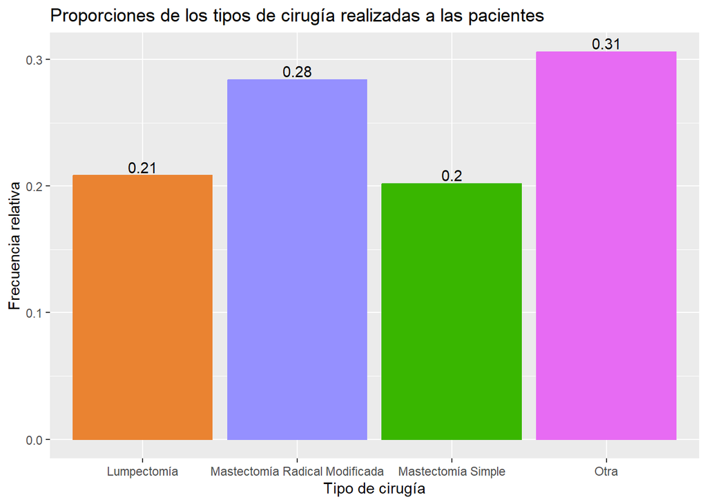

#### Análisis de `Edad`

Como es una variable numérica discreta, se analizará con descriptores numéricos

```
##                      Min                      Max                    Media
##                    29.00                    90.00                    58.84
##                  Mediana      Desviación Estándar Coeficiente de Variación
##                    58.00                    12.89                     0.22
##       Rango Intercuartil
##                    19.00
```

El coeficiente de variación es bajo, por lo que hay una baja dispersión entre los datos, lo que significa que la media es representativa para esta variable.

```r
Moda(CANCER$Edad)
```

```
## 59
## 15
```

Se observa que la edad más frecuente es 59 con 15 pacientes.

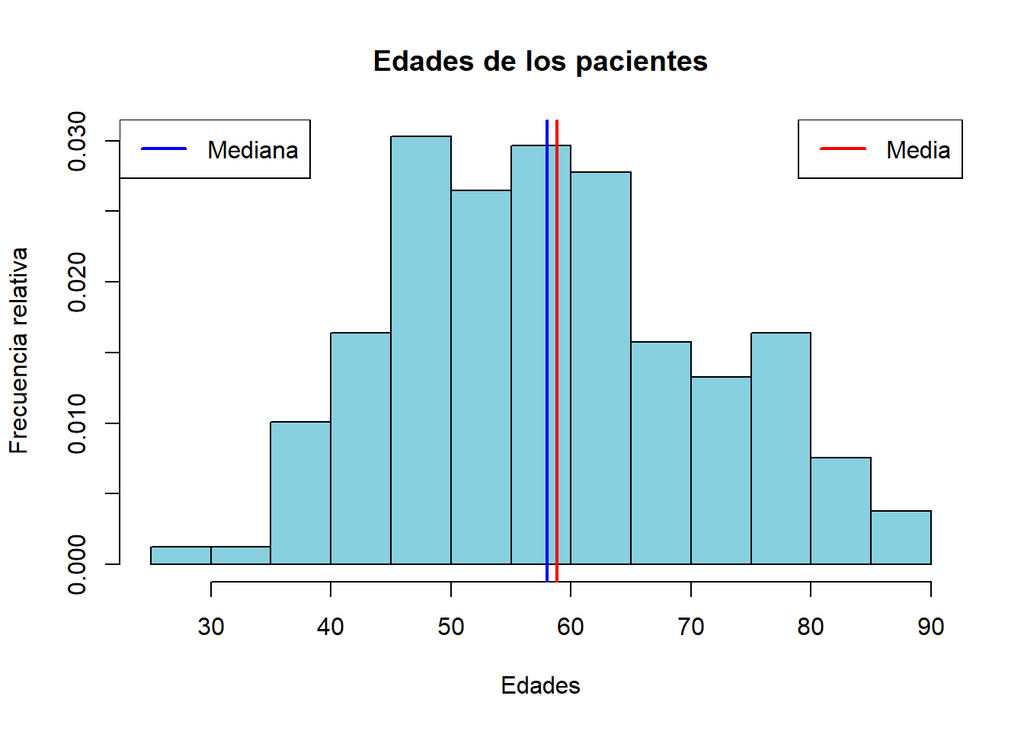

Observamos que se obtiene la siguiente relación:

$$mediana < media$$

Se sugiere que podría existir un sesgo hacia la derecha. Para comprobar esto, empleamos el índice de simetría

```r
skewness(CANCER$Edad)
```

```
## [1] 0.2827514
```

El valor obtenido es positivo, por lo que se confirma que existe un sesgo hacia la derecha. Sin embargo, puesto que el resultado se encuentra dentro del rango [-0.5 - 0.5], podríamos decir que la distribución de la variable `Edad` es aproximadamente simétrica.

### 2. Interacción entre variables

#### 2.1 Análisis bivariado

##### Análisis de `Etapa_del_Tumor` y `Estado_del_Paciente`

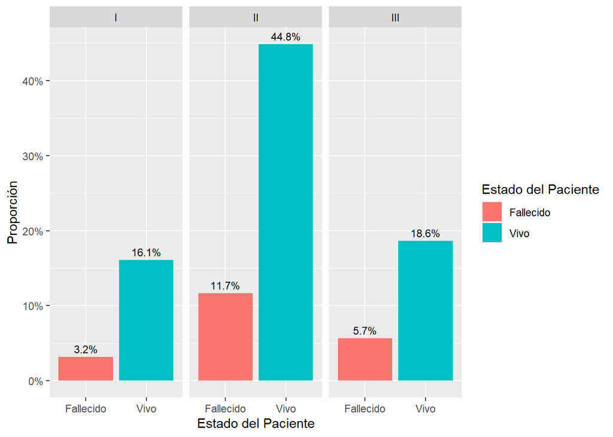

##### Análisis de `Tipo_de_Cirugía` y `Etapa_del_Tumor`

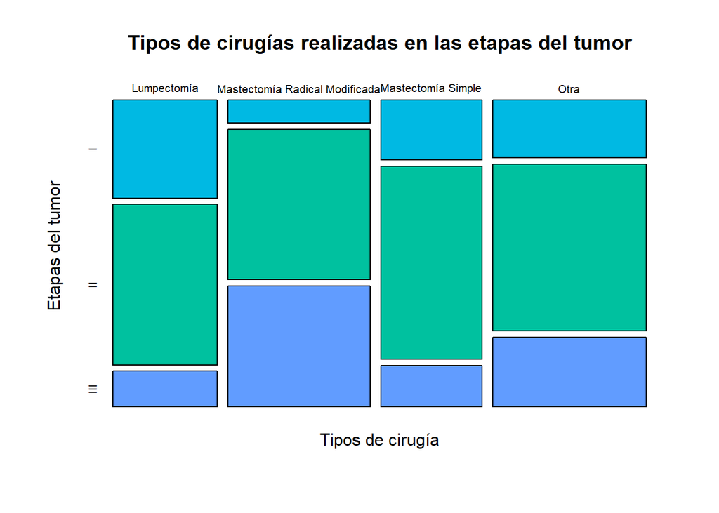

#### 2.2 Análisis de las distribuciones de las proteínas

##### Análisis de `Proteína1` respecto a `Estado_del_Paciente` y `Etapa_del_Tumor`

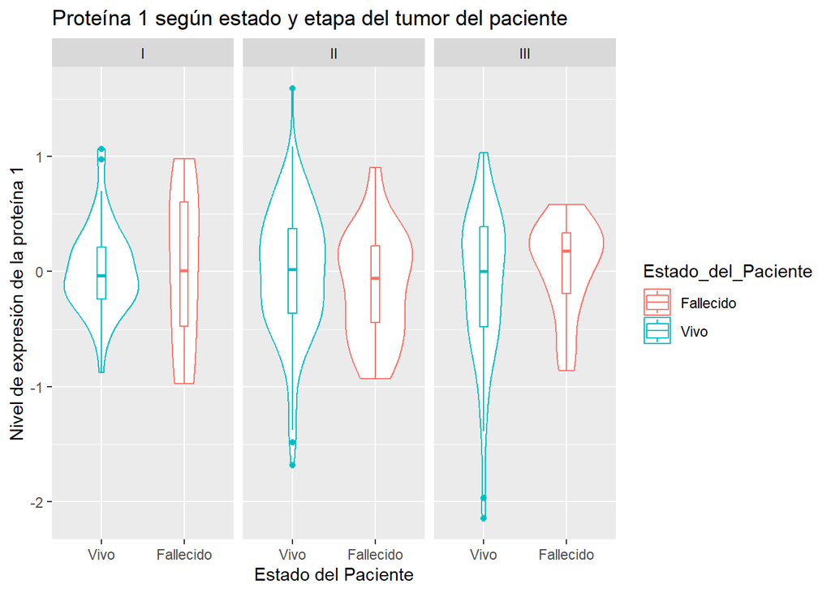

En pacientes fallecidos observamos que, a medida que la etapa progresa, el nivel de expresión de la proteína tiende a concentrarse en un nivel positivo. En pacientes vivos, observamos que, a medida que progresa la etapa, el nivel de expresión de la proteína suele tender a niveles positivos, iniciando desde un nivel negativo.

##### Análisis de `Proteína2` respecto a `Estado_del_Paciente` y `Etapa_del_Tumor`

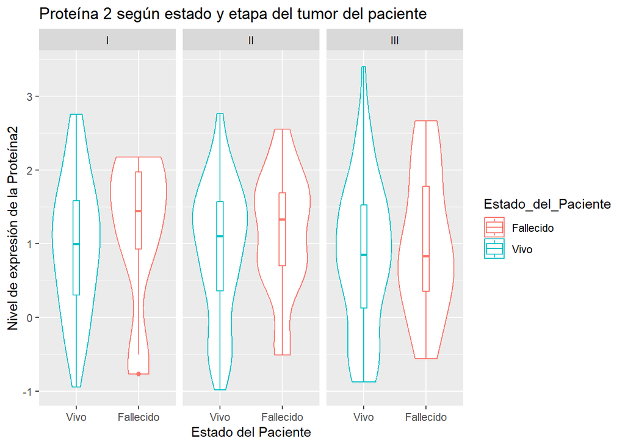

##### Análisis de `Proteína3` respecto a `Estado_del_Paciente` y `Etapa_del_Tumor`

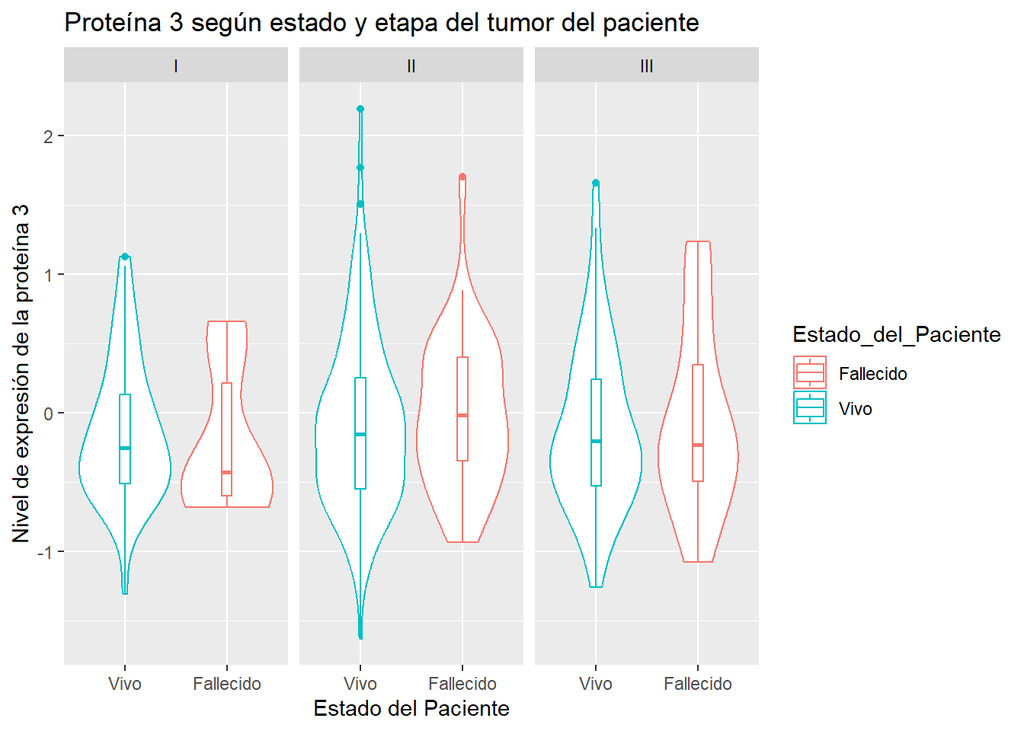

El gráfico sugiere que, a medida que progresa el cáncer, el nivel de expresión de la proteína 3 es similar en ambos estados. Ambos empiezan y terminan con un mayor nivel negativo. La diferencia es que en la etapa II, en los fallecidos toman una similar cantidad de niveles positivos y negativos.

##### Análisis de `Proteína4` respecto a `Estado_del_Paciente` y `Etapa_del_Tumor`

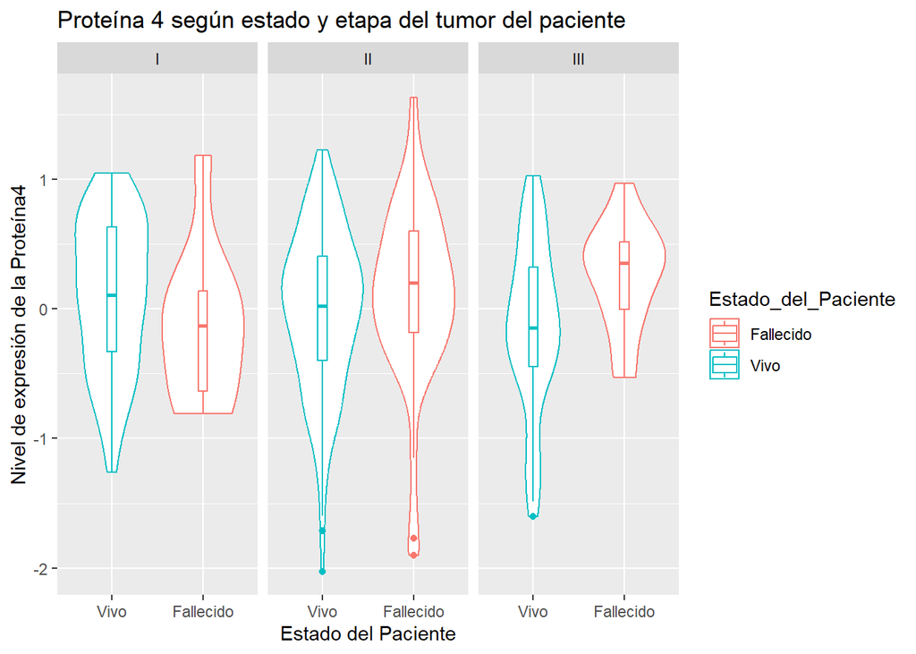

El gráfico sugiere que en pacientes vivos el nivel de expresión de la proteína 4 disminuye, distribuyéndose progresivamente hacia -1, lo que quiere decir que cada vez es menos notable. Asimismo, en pacientes fallecidos, tiende aumentar hacia 1, lo que quiere decir que va ganado presencia progresivamente.

##### Análisis de `Edad` respecto a `Estado_del_Paciente` y `Etapa_del_Tumor`

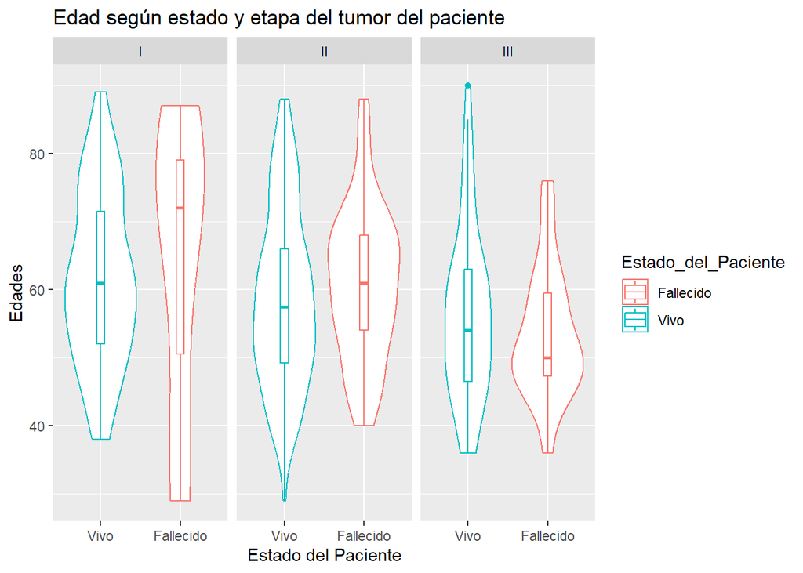

A medida que avanza la etapa del cáncer, los pacientes fallecidos son más jóvenes. En cuanto a pacientes vivos, la frecuencia de las edades es cada vez más uniforme, lo que quiere decir que mientras más avanzada sea la etapa del cáncer, las afectadas son de edades más diversas.

## III. Análisis probabilístico

### Probabilidad empírica

#### Experimento 1

Se selecciona al azar de una muestra de 317 pacientes con cáncer de mama y se observa su etapa de cáncer.

- *Justificación*

La variable `Etapa_del_Tumor` es una de las más importantes del estudio, puesto que divide a las pacientes en tres grupos que presentan características similares, modificando los comportamientos de las variables de estudio.

Un ejemplo de ello es lo siguiente:

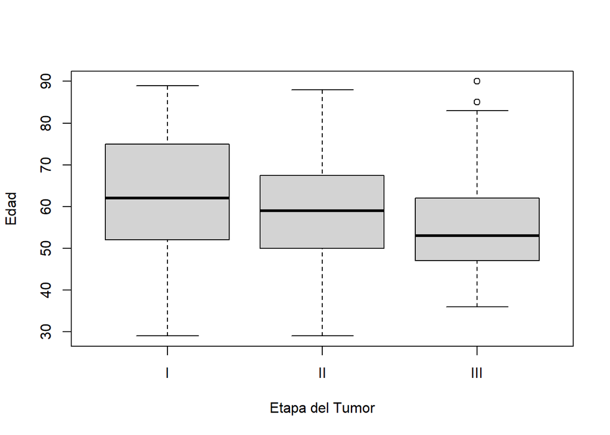

Como podemos observar, si clasificamos a los pacientes respecto a `Edad` por `Etapa_del_Tumor` podemos observar una relación clara que indica que a medida que progresa la etapa, la edad de los pacientes es menor. De esta manera podemos analizar a los pacientes según este variable de una forma más especializada.

- *Espacio muestral*

Se define el espacio muestral como las posibles etapas de cáncer que podría presentar la paciente.

categórica ordinal

$$Ω = \{I, II, III\}$$

- $E_1$: Seleccionar una paciente que se encuentre en la etapa I
- $E_2$: Seleccionar una paciente que se encuentre en la etapa II
- $E_3$: Seleccionar una paciente que se encuentre en la etapa III

```
## # A tibble: 3 x 3
##   Etapa_del_Tumor     n Probabilidad
##   <chr>           <int>        <dbl>
## 1 I                  61        0.192
## 2 II                179        0.565
## 3 III                77        0.243
```

- $P(E_1)$: 0.1924290
- $P(E_2)$: 0.5646688
- $P(E_3)$: 0.2429022

Se observa que existe una mayor proporción de pacientes en la etapa II, lo que implica que existe una mayor probabilidad de que la paciente aleatoria se encuentra en la etapa II.

#### Experimento 2

Seleccionar una persona del estudio de pacientes con cáncer de mama y observar su estado.

- *Justificación*

La variable `Estado_del_Paciente` es una de las más importantes del estudio, puesto que divide a las pacientes en dos grupos que presentan características similares para realizar un análisis más detallado, permitiendo obtener más información.

Un ejemplo de ello es lo siguiente:

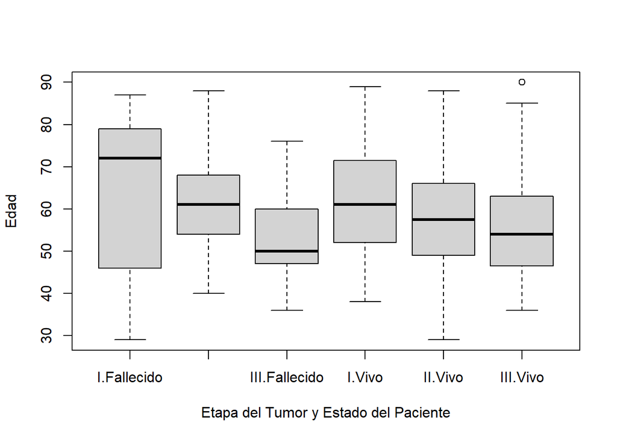

Si bien es cierto que al clasificar a los pacientes por `Etapa_del_Tumor` obtenemos información relevante, si también la segmentamos por `Estado_del_Paciente`, obtenemos datos todavía más específicos sobre la tendencia de `Edad`.

- *Espacio muestral*

Se define el espacio muestral como los posibles estados que podría presentar la paciente.

$$\Omega = \{Vivo, Fallecido\}$$
- $E_1$: Seleccionar una paciente con estado vivo - $E_2$: Seleccionar una paciente con estado fallecido

```
## # A tibble: 2 x 3
##   Estado_del_Paciente     n Probabilidad
##   <chr>               <int>        <dbl>
## 1 Vivo                  252        0.795
## 2 Fallecido              65        0.205
```

- $P(E_1)$: 0.7949527
- $P(E_2)$: 0.2050473

Se observa que existe una mayor proporción de pacientes vivas, por lo que al seleccionar aleatoriamente es más probable seleccionar a una paciente viva.